# Homework

### Question 9.7

(1)Implement a Gibbs sampler to generate a bivariate normal chain $\left(X_t, Y_t\right)$ with zero means, unit standard deviations, and correlation $0.9$.

(2)Plot the generated sample after discarding a suitable burn-in sample.

(3)Fit a simple linear regression model $Y=\beta_0+\beta_1 X$ to the sample and check the residuals of the model for normality and constant variance.

### Answer 9.7

(1)In the bivariate case, $X=(X_1,X_2)^T,X_{(-1)}=X_2,X_{(-2)}=X_1$. The conditional densities of a bivariate normal distribution are univariate normal with parameters:
$$\begin{aligned}
E\left[X_2 \mid x_1\right]&=\mu_1+\rho
\frac{\sigma_2}{\sigma_1}\left(x_1-\mu_1\right) \\
\operatorname{Var}\left(X_2 \mid x_1\right)&=\left(1-\rho^2\right)
\sigma_2^2
\end{aligned}$$
and the chain is generated by sampling from:
$$\begin{aligned}
&f\left(x_1 \mid x_2\right) \sim
\operatorname{Normal}\left(\mu_1+\frac{\rho
\sigma_1}{\sigma_2}\left(x_2-\mu_2\right),\left(1-\rho^2\right)
\sigma_1^2\right), \\
&f\left(x_2 \mid x_1\right) \sim
\operatorname{Normal}\left(\mu_2+\frac{\rho
\sigma_2}{\sigma_1}\left(x_1-\mu_1\right),\left(1-\rho^2\right)
\sigma_2^2\right) .
\end{aligned}$$
For a bivariate distribution $(X_1, X_2)$, at each iteration the Gibbs sampler: - Sets $(x_1, x_2) = X(t − 1)$;

- Generates $X^*_1(t)$ from $f(X_1|x_2)$;
- Updates $x_1 = X^*_1(t)$;
- Generates $X^*_2(t)$ from $f(X_2|x_1)$;
- Sets $X(t)=(X^*_1(t), X^*_2(t))$. The codes of generating a bivariate normal chain with parameters$\mu_1=\mu_2=0,\sigma_1=\sigma_2=1,\rho=0.9$ by the above Gibbs sampler is as below:

```r
rm(list=ls())
set.seed(1234)
N = 5000
X = matrix(0, N, 2)
rho = 0.9;mu1 = 0;mu2 = 0;sigma1 = 1;sigma2 = 1
s1 = sqrt(1 - rho^2) * sigma1
s2 = sqrt(1 - rho^2) * sigma2
X[1, ] = c(mu1, mu2)
for (i in 2:N) {
x2 = X[i - 1, 2]
m1 = mu1 + rho * (x2 - mu2) * sigma1/sigma2
X[i, 1] = rnorm(1, m1, s1)
x1 = X[i, 1]
m2 = mu2 + rho * (x1 - mu1) * sigma2/sigma1
X[i, 2] = rnorm(1, m2, s2) }
head(X)
```

```
##            [,1]       [,2]
## [1,]  0.0000000  0.0000000
## [2,] -0.5261478 -0.3526044
## [3,]  0.1553530 -0.8826482
## [4,] -0.6073323 -0.3260144
## [5,] -0.5439363 -0.7278140
## [6,] -0.9010715 -1.1989228
```

(2)Without loss of generality, we choose $500$ as burn-in size. The plot of the generated chain (after discarding the burn-in sample) is shown below:

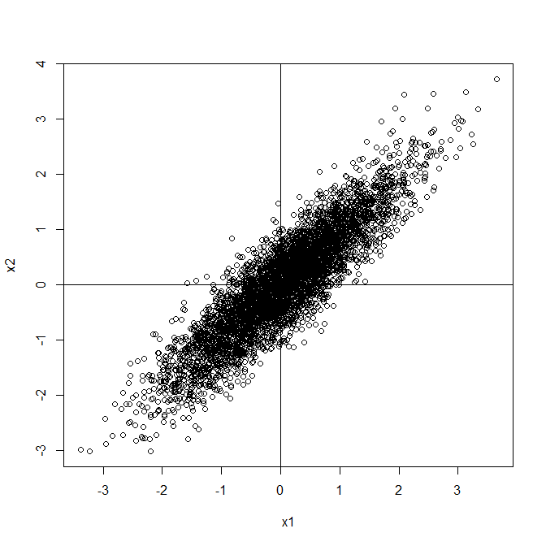

```r
burn=500
b=burn+1
x=X[b:N, ]
x1=x[, 1]
x2=x[, 2]
plot(x1,x2)
abline(h = 0, v = 0)
```

(3)Fit the simple linear regression model $Y=\beta_0+\beta_1 X$ to the sample:

```r
lm1=lm(x2 ~ x1)
summary(lm1)
```

```
##
## Call:
## lm(formula = x2 ~ x1)
##
## Residuals:
##     Min      1Q  Median      3Q     Max
## -1.4489 -0.2894  0.0055  0.2859  1.5858
##
## Coefficients:
##              Estimate Std. Error t value Pr(>|t|)
## (Intercept) -0.006576   0.006464  -1.017    0.309
## x1           0.902580   0.006692 134.866   <2e-16 ***
## ---
## Signif. codes:  0 '***' 0.001 '**' 0.01 '*' 0.05 '.' 0.1 ' ' 1
##
## Residual standard error: 0.433 on 4498 degrees of freedom
## Multiple R-squared:  0.8017, Adjusted R-squared:  0.8017
## F-statistic: 1.819e+04 on 1 and 4498 DF,  p-value: < 2.2e-16
```

From above, the fitted model is $\hat{Y}=-0.006576+0.902580 X$. The coefficients of the fitted model match the parameters of the target distribution well. Next, give the normal probability plot of the residuals:

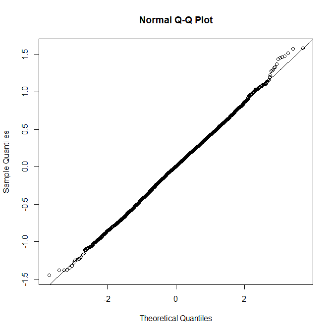

```r
qqnorm(lm1$res)
qqline(lm1$res)
```

It can be seen from the figure that most of the points are approximately distributed along a straight line, and there is no serious violation of the assumption of normality of regression. Then, give the plot of residuals versus predicted values of response variables:

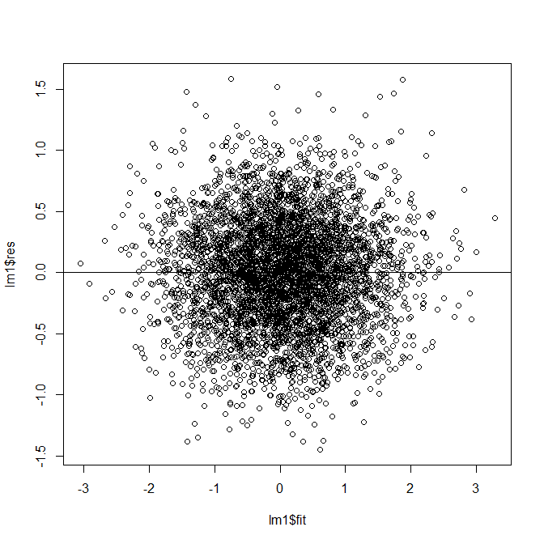

```r
plot(lm1$fit, lm1$res)
abline(h = 0)
```

As can be seen from the figure, the residuals are basically contained in a horizontal band, and the error variance is constant with respect to the response variable. Thus, the assumption of equal variance in this model does not have obvious shortcomings.

(4)Get four chains here with different initial values:

```r
rm(list=ls())
set.seed(1234)
N = 5000
#chain1
X1 = matrix(0, N, 2)
rho = 0.9;mu1 = 0;mu2 = 0;sigma1 = 1;sigma2 = 1
s1 = sqrt(1 - rho^2) * sigma1
s2 = sqrt(1 - rho^2) * sigma2
X1[1, ] = c(mu1, mu2)
for (i in 2:N) {
x2 = X1[i - 1, 2]
m1 = mu1 + rho * (x2 - mu2) * sigma1/sigma2
X1[i, 1] = rnorm(1, m1, s1)
x1 = X1[i, 1]
m2 = mu2 + rho * (x1 - mu1) * sigma2/sigma1
X1[i, 2] = rnorm(1, m2, s2) }
#chain2
X2 = matrix(0, N, 2)
X2[1, ] =c(-1,1)
for (i in 2:N) {
x2 = X2[i - 1, 2]
m1 = mu1 + rho * (x2 - mu2) * sigma1/sigma2
X2[i, 1] = rnorm(1, m1, s1)
x1 = X2[i, 1]
m2 = mu2 + rho * (x1 - mu1) * sigma2/sigma1
X2[i, 2] = rnorm(1, m2, s2) }
#chain3
X3 = matrix(0, N, 2)
X3[1, ] =c(2,3)
for (i in 2:N) {
x2 = X3[i - 1, 2]
m1 = mu1 + rho * (x2 - mu2) * sigma1/sigma2
X3[i, 1] = rnorm(1, m1, s1)
x1 = X3[i, 1]
m2 = mu2 + rho * (x1 - mu1) * sigma2/sigma1
X3[i, 2] = rnorm(1, m2, s2) }
#chain4
X4 = matrix(0, N, 2)
X4[1, ] =c(-3,-2)
for (i in 2:N) {
x2 = X4[i - 1, 2]
m1 = mu1 + rho * (x2 - mu2) * sigma1/sigma2
X4[i, 1] = rnorm(1, m1, s1)
x1 = X4[i, 1]
m2 = mu2 + rho * (x1 - mu1) * sigma2/sigma1
X4[i, 2] = rnorm(1, m2, s2) }
```

Get the first and the second variable respectively:

```r
XX=cbind(X1[,1], X2[,1], X3[,1], X4[,1])
YY=cbind(X1[,2], X2[,2], X3[,2], X4[,2])
```

The codes of getting $\hat{R}$ is as below:

```r
Gelman.Rubin = function(psi) {
psi = as.matrix(psi)
n = ncol(psi)
k = nrow(psi)
psi.means = rowMeans(psi) #row means
B = n * var(psi.means) #between variance est.
psi.w = apply(psi, 1, "var") #within variances
W = mean(psi.w) #within est.
v.hat = W*(n-1)/n + (B/n) #upper variance est.
r.hat = v.hat / W #G-R statistic
return(r.hat)
}

#compute diagnostic statistics
psi <- apply(XX, 1, cumsum)
for (i in 1:nrow(psi))
psi[i,] <- psi[i,] / (1:ncol(psi))
print(Gelman.Rubin(psi))
```

```
## [1] 1.000173
```

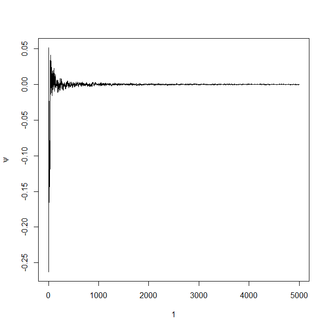

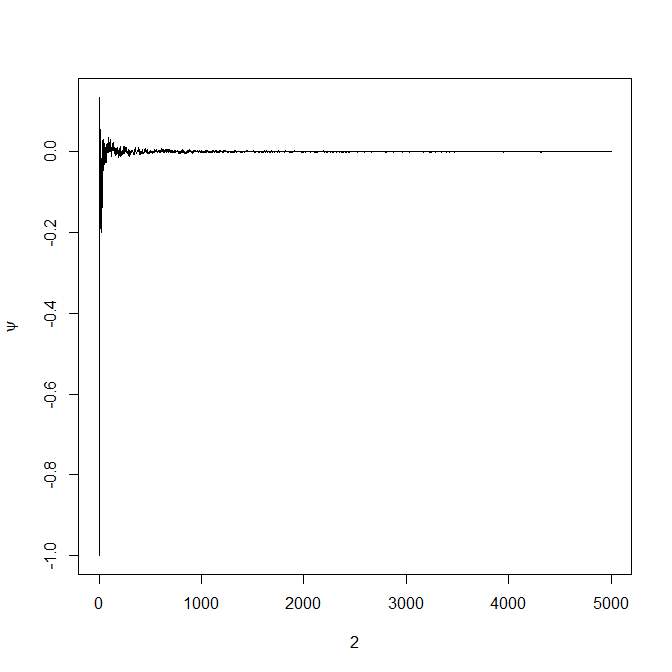

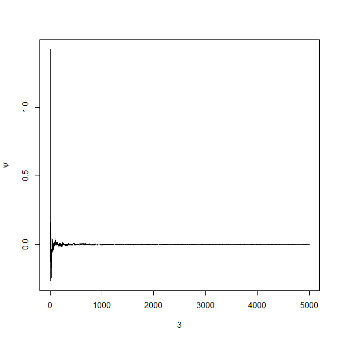

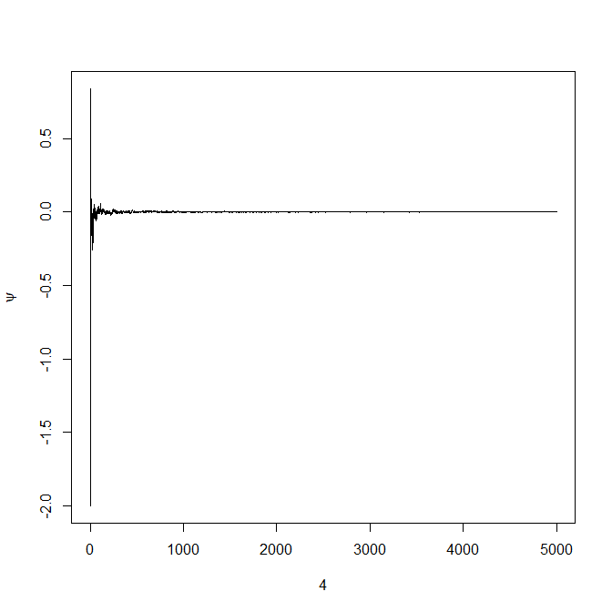

```r
#plot psi for the four chains
for (i in 1:4)
plot(psi[i, 1:N], type="l",
xlab=i, ylab=bquote(psi))
```

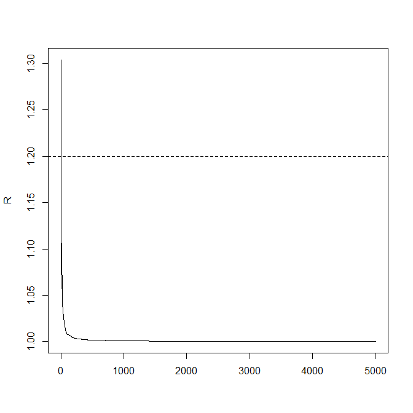

```r
#plot the sequence of R-hat statistics
rhat <- rep(0, N)
for (j in 1:N)
rhat[j] <- Gelman.Rubin(psi[,1:j])
plot(rhat[1:N], type="l", xlab="", ylab="R")
abline(h=1.2, lty=2)
```

From above, the plots of the four sequences of the summary statistic $\psi$(the mean) show that each chain appears to have converged to the target distribution. On the other hand, we use the Gelman-Rubin method to monitor convergence of the chain and calculate the value$\hat{R}$. Cause $\hat{R}=1.000173$ is smaller than $1.2$, it seems that the chain converge quickly to the target distribution.

```r
#compute diagnostic statistics
psi <- apply(YY, 1, cumsum)
for (i in 1:nrow(psi))
psi[i,] <- psi[i,] / (1:ncol(psi))
print(Gelman.Rubin(psi))
```

```
## [1] 1.000122
```

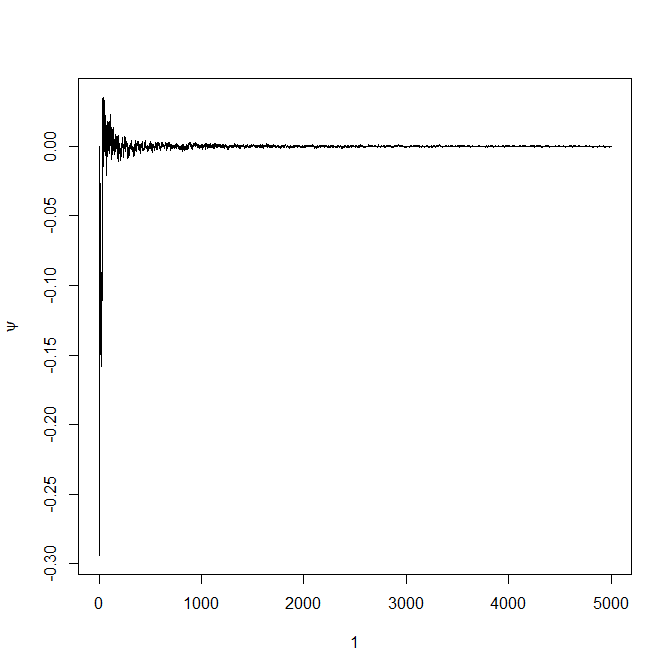

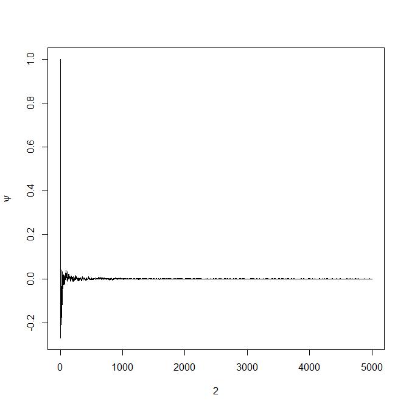

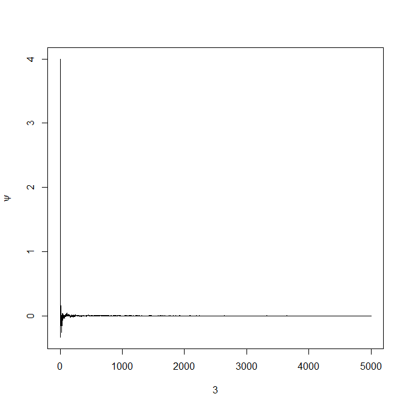

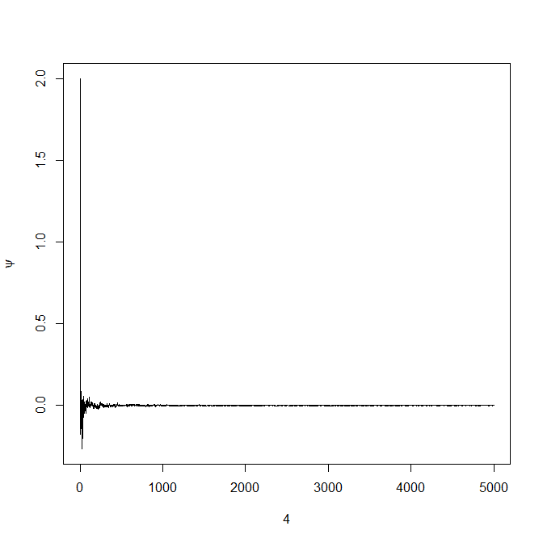

```r
#plot psi for the four chains
for (i in 1:4)
plot(psi[i, 1:N], type="l",
xlab=i, ylab=bquote(psi))
```

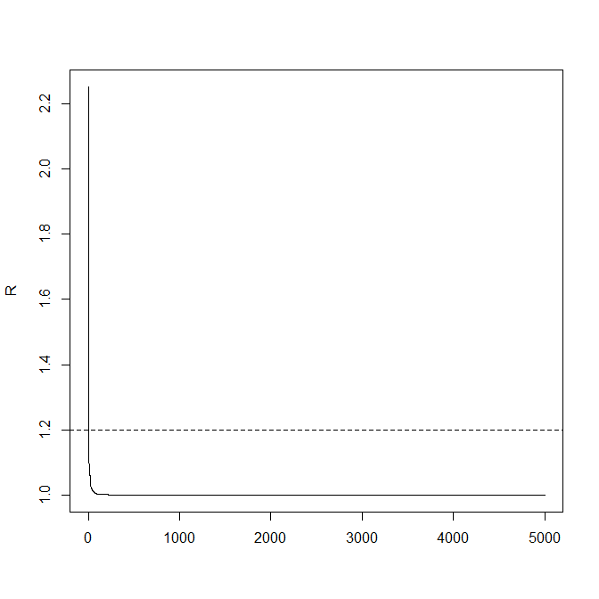

```r
#plot the sequence of R-hat statistics
rhat <- rep(0, N)
for (j in 1:N)
rhat[j] <- Gelman.Rubin(psi[,1:j])
plot(rhat[1:N], type="l", xlab="", ylab="R")
abline(h=1.2, lty=2)
```

From above, the plots of the four sequences of the summary statistic $\psi$(the mean) show that each chain appears to have converged to the target distribution. On the other hand, we use the Gelman-Rubin method to monitor convergence of the chain and calculate the value$\hat{R}$. Cause $\hat{R}=1.000122$ is smaller than $1.2$, it seems that the chain converge quickly to the target distribution.

## Homework8

### Question 1

Test for mediating effect:$H_0:\alpha \beta=0$ vs $H_1:\alpha \beta\neq0$. The test statistic is $T=\frac{\hat\alpha \hat\beta}{\widehat {cov}(\hat\alpha,\hat\beta)}$ and the rejection region is $\{|T|>|T_0|\}$.

Set a random simulation study to examine the performance of the three permutation tests, considering the model:
$$\begin{aligned}M&=a_M+\alpha
X+e_M\\Y&=a_Y+\beta M+\gamma X+e_Y\\ \end{aligned}$$
$$e_M,e_Y\sim N(0,1)$$
and three parameters combinations:
$$\begin{aligned}\alpha=0,\beta=0,\gamma=1\\\alpha=0,\beta=1,\gamma=1\\\alpha=1,\beta=0,\gamma=1\end{aligned}$$
.

### Answer 1

$\alpha=0,\beta=0,\gamma=1$

```r
rm(list=ls())
set.seed(99999)
#generate sample X,M,Y
N=10000;alpha=0;beta=0;gamma=1
X=rnorm(N,0,1);em=rnorm(N,0,1);ey=rnorm(N,0,1)
M=alpha*X+em
Y=beta*M+gamma*X+ey
#original test
library(bda)
#mediation.test(M,X,Y)
t01=mediation.test(M,X,Y)[1,1]
p1.origin=mediation.test(M,X,Y)[2,1]
p1.origin
```

```
## [1] 0.2344015
```

```r
#permutation test
m=1000
XX=matrix(0,nrow = N,ncol = m)
YY=matrix(0,nrow = N,ncol = m)
t=numeric(0)
for (i in 1:m) {
  XX[,i]=  X[sample(1:N,N)]
  YY[,i]=  Y[sample(1:N,N)]
  t[i]=mediation.test(M,XX[,i],YY[,i])[1,1]
}
p1.permutation=sum(abs(t)>abs(t01))/m
p1.permutation
```

```
## [1] 0.022
```

$\alpha=0,\beta=1,\gamma=1$

```r
rm(list=ls())
set.seed(99999)
#generate sample X,M,Y
N=10000;alpha=0;beta=1;gamma=1
X=rnorm(N,0,1);em=rnorm(N,0,1);ey=rnorm(N,0,1)
M=alpha*X+em
Y=beta*M+gamma*X+ey
#original test
library(bda)
#mediation.test(M,X,Y)
t02=mediation.test(M,X,Y)[1,1]
p2.origin=mediation.test(M,X,Y)[2,1]
p2.origin
```

```
## [1] 0.1844982
```

```r
#permutation test
m=1000
XX=matrix(0,nrow = N,ncol = m)
t=numeric(0)
for (i in 1:m) {
  XX[,i]=  X[sample(1:N,N)]
  t[i]=mediation.test(M,XX[,i],Y)[1,1]
}
p2.permutation=sum(abs(t)>abs(t02))/m
p2.permutation
```

```
## [1] 0.167
```

$\alpha=1,\beta=0,\gamma=1$

```r
rm(list=ls())
set.seed(99999)
#generate sample X,M,Y
N=10000;alpha=1;beta=0;gamma=1
X=rnorm(N,0,1);em=rnorm(N,0,1);ey=rnorm(N,0,1)
M=alpha*X+em
Y=beta*M+gamma*X+ey
#original test
library(bda)
#mediation.test(M,X,Y)
t03=mediation.test(M,X,Y)[1,1]
p3.origin=mediation.test(M,X,Y)[2,1]
p3.origin
```

```
## [1] 0.007437869
```

```r
#permutation test
m=1000
YY=matrix(0,nrow = N,ncol = m)
t=numeric(0)
for (i in 1:m) {
  YY[,i]=  X[sample(1:N,N)]
  t[i]=mediation.test(M,X,YY[,i])[1,1]
}
p3.permutation=sum(abs(t)>abs(t03))/m
p3.permutation
```

```
## [1] 0.005
```

From above, it seems that the p-values obtained from the hypothesis test using permutation under the three parameter models are all smaller than the original test. Thus, we can’t control the probability of type-I error of $H_0:\alpha \beta=0$ by controlling any type-I error of the three parameter combinations. We can’t use the form of the three parameters proposed as a substitute for $H_0:\alpha \beta=0$.

### Question 2

Consider the model
$$P(Y=1 \mid
X_1,X_2,X_3)=\frac{exp(\alpha+b_1x_1+b_2x_2+b_3x_3)}{1+exp(\alpha+b_1x_1+b_2x_2+b_3x_3)},$$
$$X_1\sim P(1),X_2\sim Exp(1),X_3\sim
B(1,0.5)$$
.

(1)Write a R function to realize the above function with the input values $N,b_1,b_2,b_3,f_0$ and the output values $\alpha$.

(2)Use the R function with the input values $N=10^6,b_1=0,b_2=1,b_3=-1$ and $f_0=0.1,0.01,0.001,0.0001$.

(3)Plot the scattered figure $-log(f_0)$ vs $\alpha$.

### Answer 2

(1)The algorithm is as below:

1. Specify $f_0, b_1, b_2,b_3, N$(large enough);
2. Generate $\left(x_{1 i}, x_{2 i},x_{3 i}\right), i=1, \ldots, N$;
3. Write a function with $\alpha$ to approximate $P(D=1)-f_0$:
   $$g(\alpha)=\frac{1}{N} \sum_{i=1}^N \frac{1}{1+e^{-\alpha-b_1 x_{1 i}-b_2
   x_{2 i}-b_3x_{3 i}}}-f_0$$
4. Solve $g(\alpha)=0$ using uniroot.

```r
rm(list = ls())
f <- function(N,b1,b2,b3,f0){
  g <- function(alpha){
  tmp <- exp(-alpha-b1*x1-b2*x2-b3*x3)
  p<-1/(1+tmp)
  mean(p) - f0
  }
  solution <- uniroot(g,c(-20,0))
  alpha <- solution$root
  alpha
}
```

(2)Use the above function:

```r
set.seed(1234)
N=10^6;b1=0;b2=1;b3=-1;
f0=c(0.1,0.01,0.001,0.0001)
x1 <- rpois(N,1);x2=rexp(N,1); x3 <- sample(0:1,N,replace=TRUE)
alpha=c(f(N,b1,b2,b3,f0[1]),f(N,b1,b2,b3,f0[2]),f(N,b1,b2,b3,f0[3]),f(N,b1,b2,b3,f0[4]))
data=data.frame(f0=f0,alpha=alpha)
data
```

```
##      f0      alpha
## 1 1e-01  -3.169882
## 2 1e-02  -6.069290
## 3 1e-03  -8.702499
## 4 1e-04 -11.219914
```

(3)Give the plot:

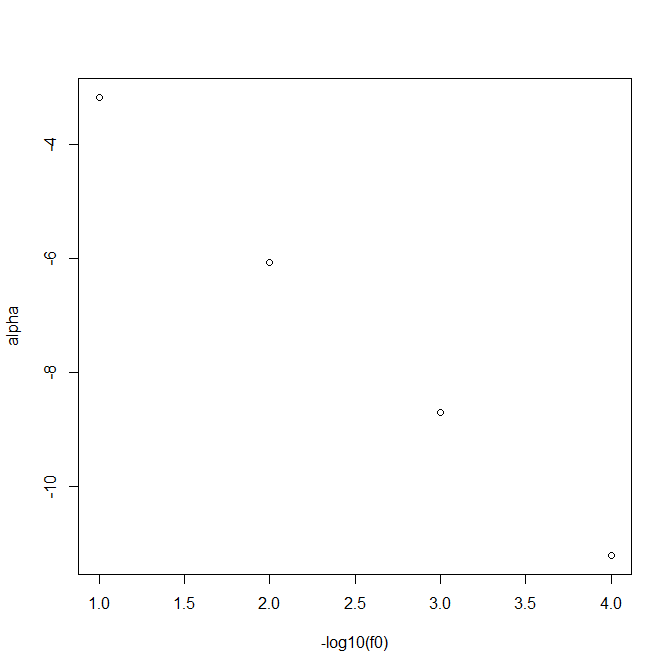

```r
plot(x=-log10(f0),alpha)
```

From the plot, it vividly shows the tendency of monotonical decrease.

## Homework9

### Question class work

Define that $X_1, \cdots , X_n \sim \text{Exp}(\lambda)$. For some reason, we just know that $X_i$ falls in an interval $(u_i,v_i)$, where $u_i$ and $v_i$ are two non-random known constants, and $u_i<v_i$. This type of data is called interval deleted data.

(1)Try to directly maximize the likelihood function of the observed data and use EM algorithm to solve the MLE of $\lambda$, and prove that the two are equal.

(2)Let the observation data of $(u_i,v_i)$, $i=1, \cdots n$ $(n=10)$ be $(11,12),$ $(8,9),$ $(27,28),$ $(13,14),$ $(16,17),$ $(0,1),$ $(23,24),$ $(10,11),$ $(24,25),$ $(2,3)$. Try to program the numerical solutions of MLE of $\lambda$ of the above two algorithms respectively.

### Answer class work

(1)Using to method to solve the MLE of $\lambda$:

- The maximum likelihood estimation of the observed data directly:

$$\begin{aligned}
L_o(\lambda) & = \prod_{i=1}^n P_{\lambda} (u_i \le X_i \le v_i) \\
& = \prod_{i=1}^n \int_{u_i}^{v_i} \lambda e^{-\lambda x} \text{d} x
\\
& = \prod_{i=1}^n(e^{-\lambda u_i}-e^{-\lambda v_i})
\end{aligned}$$

$$\begin{aligned}
\frac{\partial lnL_o(\lambda)}{\partial \lambda} & = 0\\
\sum_{i=1}^{n} \frac{v_ie^{-\hat{\lambda} v_i}-u_ie^{-\hat{\lambda}
u_i}}{e^{-\hat{\lambda} v_i}-e^{-\hat{\lambda} u_i}} & =0
\end{aligned}$$

- Use EM algorithm to solve the maximum likelihood estimation:

Supplement the value of $X_i$, $i=1,2, \cdots,n$. Then we have:
$$\begin{aligned}
L_c(\lambda)&=\prod_{i=1}^n \lambda e^{-\lambda X_i}=\lambda^n
e^{\sum_{i=1}^n X_i}\\
ln L_c(\lambda)&= n ln\lambda - \lambda \sum_{i=1}^n X_i
\end{aligned}$$

$$\begin{aligned}
Q(\lambda, \hat{\lambda}^{(t)}) & = E[ n ln\lambda - \lambda
\sum_{i=1}^n X_i \mid \hat{\lambda}^{(t)}, X_i, X_i \in (u_i,v_i)] \\
& = n ln\lambda - \lambda \sum_{i=1}^n E[X_i \mid
\hat{\lambda}^{(t)}, X_i, X_i \in (u_i,v_i)]
\end{aligned}$$

$$E [X_i \mid \hat{\lambda}^{(t)}, X_i, X_i \in (u_i,v_i)] = \frac{\{
E[X_i]-E[X_i \mid \hat{\lambda}^{(t)}, X_i, X_i \in (0,u_i)]P(0< X_i
<u_i \mid \hat{\lambda}^{(t)})
-E[X_i \mid \hat{\lambda}^{(t)}, X_i, X_i \in (v_i,\infty)]P(v_i< X_i
<\infty \mid \hat{\lambda}^{(t)})\}} { P(u_i<X_i<v_i \mid )}$$
By some simple derivations, we have:
$$E [X_i \mid \hat{\lambda}^{(t)}, X_i, X_i \in (u_i,v_i)]
= \frac{1}{\lambda} + \frac{u_i e^{-\lambda u_i} - v_i e^{-\lambda
v_i}}{e^{-\lambda u_i} - e^{-\lambda v_i}}$$
$$Q(\lambda, \hat{\lambda}^{(t)}) = n ln\lambda - \lambda
\sum_{i=1}^n \left( \frac{1}{\hat{\lambda}^{(t)}} + \frac{u_i
e^{-\hat{\lambda}^{(t)} u_i} - v_i e^{-\hat{\lambda}^{(t)}
v_i}}{e^{-\hat{\lambda}^{(t)} u_i} - e^{-\hat{\lambda}^{(t)} v_i}}
\right)$$
Then:
$$\begin{aligned}
&\frac{\partial Q(\lambda, \hat{\lambda}^{(t)})}{\partial
\lambda} = 0 \\
&\hat{\lambda}^{(t+1)} = \frac{n}{ \sum_{i=1}^n \left(
\frac{1}{\hat{\lambda}^{(t)}} + \frac{u_i e^{-\hat{\lambda}^{(t)} u_i} -
v_i e^{-\hat{\lambda}^{(t)} v_i}}{e^{-\hat{\lambda}^{(t)} u_i} -
e^{-\hat{\lambda}^{(t)} v_i}} \right)}
\end{aligned}$$
If the iteration converges, then we have the same result with the method of solving maximum likelihood estimation of the observed data directly:
$$\begin{aligned}
\hat{\lambda}^{(t)}&=\frac{n}{ \sum_{i=1}^n \left(
\frac{1}{\hat{\lambda}^{(t)}} + \frac{u_i e^{-\hat{\lambda}^{(t)} u_i} -
v_i e^{-\hat{\lambda}^{(t)} v_i}}{e^{-\hat{\lambda}^{(t)} u_i} -
e^{-\hat{\lambda}^{(t)} v_i}} \right)} \\
& \Rightarrow \sum_{i=1}^{n} \frac{v_ie^{-\hat{\lambda}
v_i}-u_ie^{-\hat{\lambda} u_i}}{e^{-\hat{\lambda} v_i}-e^{-\hat{\lambda}
u_i}} =0
\end{aligned}$$

(2)Solve the maximum likelihood estimation of the observed data directly:

```r
rm(list = ls())
u=c(11,8,27,13,16,0,23,10,24,2)
v=c(12,9,28,14,17,1,24,11,25,3)
f=function(lambda){
  I=numeric(10)
  J=numeric(10)
  for (i in 1:10) {
    I[i]=v[i]*exp((-1)*(lambda*v[i]))-u[i]*exp((-1)*(lambda*u[i]))
    J[i]=exp((-1)*(lambda*u[i]))-exp((-1)*(lambda*v[i]))
  }
  sum(I/J)
}
solution=uniroot(f,c(0,10))
solution
```

```
## $root
## [1] 0.07196821
##
## $f.root
## [1] 0.01019994
##
## $iter
## [1] 11
##
## $init.it
## [1] NA
##
## $estim.prec
## [1] 6.103516e-05
```

Use EM algorithm to solve the maximum likelihood estimation:

```r
rm(list = ls())
u=c(11,8,27,13,16,0,23,10,24,2)
v=c(12,9,28,14,17,1,24,11,25,3)
f=function(lambda){
  I=numeric(10)
  J=numeric(10)
  for (i in 1:10) {
    I[i]=u[i]*exp((-1)*(lambda*u[i]))-v[i]*exp((-1)*(lambda*v[i]))
    J[i]=exp((-1)*(lambda*u[i]))-exp((-1)*(lambda*v[i]))
  }
  sum(I/J)
}
EM=function(lambda2,n,max.it=10000,eps=1e-5){

  i=1
  lambda1=1


  while( abs(lambda1 - lambda2) >= eps){
    lambda1 = lambda2
    lambda2 = n/((n/lambda1)+f(lambda1))
    if(i == max.it) break
    i = i + 1
  }
  return(lambda2)
}

initial=c(0.5,0.1,0.01)
estimate=c(EM(lambda2=0.5,n=10,max.it=10000,eps=1e-5),
EM(lambda2=0.1,n=10,max.it=10000,eps=1e-5),
EM(lambda2=0.01,n=10,max.it=10000,eps=1e-5))
data.frame(initial,estimate)
```

```
##   initial  estimate
## 1    0.50 0.0719735
## 2    0.10 0.0719735
## 3    0.01 0.0719735
```

From above, it seems that the values of the estimation $\hat\lambda_{MLE}$ obtained by EM algorithm($0.0719735$) and the direct solution method($0.07196821$) are almost the same.

### Question 2.1.3

4. Why do you need to use unlist() to convert a list to an atomic vector? Why doesn’t as.vector() work?
5. Why is 1 == “1” true? Why is -1 < FALSE true? Why is “one” < 2 false?

### Answer 2.1.3

4. To get rid of the nested structure. Given a list structure x, unlist() simplifies it to produce a vector which contains all the atomic components which occur in x. For as.vector, a vector (atomic or of type list or expression). All attributes are removed from the result if it is of an atomic mode, but not in general for a list result. In other words, as.vector removes all attributes including names for results of atomic mode (but not those of mode “list” nor “expression”).
5. These comparisons are carried out by operator-functions (==, <), which force their arguments to a common type. In these examples, these types will be character, double and character: 1 will be forced to “1”, FALSE is represented as 0 and 2 turns into “2”(numbers precede letters in lexicographic order or “one” comes after “2” in ASCII).

### Question 2.3.1

1. What does dim() return when applied to a vector?
2. If is.matrix(x) is TRUE, what will is.array(x) return?

### Answer 2.3.1

1. NULL

```r
rm(list = ls())
a=c(1,2,3)
dim(a)
```

[output not shown]

2. TRUE. (A two-dimensional array is the same thing as a matrix.)

```r
rm(list = ls())
a=matrix(1:9,nrow=3)
is.matrix(a)
```

```
## [1] TRUE
```

```r
is.array(a)
```

```
## [1] TRUE
```

### Question 2.4.5

1. What attributes does a data frame possess?
2. What does as.matrix() do when applied to a data frame with columns of different types?
3. Can you have a data frame with 0 rows? What about 0 columns?

### Answer 2.4.5

1. A data frame possesses names, row.names and class.
2. The method for data frames will return if there is only atomic columns and any non-(numeric/logical/complex) column, applying as.vector to factors and format to other non-character columns. Otherwise the usual coercion hierarchy (logical < integer < double < complex) will be used. For example, all-logical data frames will be forced to a logical matrix, mixed logical-integer will give a integer matrix.

```r
rm(list = ls())
a=1:3
b=c("1","2","3")
c=c(1.233,2.455,88.888)
d=c(TRUE,TRUE,FALSE)
e=c(FALSE,FALSE,TRUE)
data1=data.frame(a,b,c,d)
as.matrix(data1)
```

```
##      a   b   c        d
## [1,] "1" "1" " 1.233" "TRUE"
## [2,] "2" "2" " 2.455" "TRUE"
## [3,] "3" "3" "88.888" "FALSE"
```

```r
data2=data.frame(d,e)
as.matrix(data2)
```

```
##          d     e
## [1,]  TRUE FALSE
## [2,]  TRUE FALSE
## [3,] FALSE  TRUE
```

```r
data3=data.frame(a,d,e)
as.matrix(data3)
```

```
##      a d e
## [1,] 1 1 0
## [2,] 2 1 0
## [3,] 3 0 1
```

3. Yes, we can have a data frame with 0 rows and both dimensions can be 0:

```r
data("iris")
iris[FALSE,]
```

```
## [1] Sepal.Length Sepal.Width  Petal.Length Petal.Width  Species
## <0 行> (或0-长度的row.names)
```

```r
iris[ , FALSE]
```

```
## data frame with 0 columns and 150 rows
```

```r
iris[FALSE, FALSE]
```

```
## data frame with 0 columns and 0 rows
```

## Homework10

### Question Page_204 exercise2

The function below scales a vector so it falls in the range $[0,1]$. How would you apply it to every column of a data frame? How would you apply it to every numeric column in a data frame?

```r
scale01 <- function(x) {
rng <- range(x, na.rm = TRUE)
(x - rng[1]) / (rng[2] - rng[1])
}
```

### Answer Page_204 exercise2

Since this function needs numeric input, we can check this via an if clause. If we want to return non-numeric input columns, these can be supplied to the else argument of the $if()$ function:

```r
scale01 <- function(x) {
rng <- range(x, na.rm = TRUE)
(x - rng[1]) / (rng[2] - rng[1])
}
library(MASS)
head(UScereal)
```

```
##                           mfr calories   protein      fat   sodium     fibre
## 100% Bran                   N 212.1212 12.121212 3.030303 393.9394 30.303030
## All-Bran                    K 212.1212 12.121212 3.030303 787.8788 27.272727
## All-Bran with Extra Fiber   K 100.0000  8.000000 0.000000 280.0000 28.000000
## Apple Cinnamon Cheerios     G 146.6667  2.666667 2.666667 240.0000  2.000000
## Apple Jacks                 K 110.0000  2.000000 0.000000 125.0000  1.000000
## Basic 4                     G 173.3333  4.000000 2.666667 280.0000  2.666667
##                              carbo   sugars shelf potassium vitamins
## 100% Bran                 15.15152 18.18182     3 848.48485 enriched
## All-Bran                  21.21212 15.15151     3 969.69697 enriched
## All-Bran with Extra Fiber 16.00000  0.00000     3 660.00000 enriched
## Apple Cinnamon Cheerios   14.00000 13.33333     1  93.33333 enriched
## Apple Jacks               11.00000 14.00000     2  30.00000 enriched
## Basic 4                   24.00000 10.66667     3 133.33333 enriched
```

```r
head(data.frame(lapply(UScereal, function(x) if (is.numeric(x)) scale01(x) else x)))
```

```
##   mfr  calories   protein       fat    sodium      fibre       carbo    sugars
## 1   N 0.4156954 1.0000000 0.3333333 0.5000000 1.00000000 0.080475097 0.8701299
## 2   K 0.4156954 1.0000000 0.3333333 1.0000000 0.90000000 0.185925105 0.7251082
## 3   K 0.1282051 0.6375150 0.0000000 0.3553846 0.92400001 0.095238029 0.0000000
## 4   G 0.2478633 0.1684168 0.2933333 0.3046154 0.06600000 0.060439492 0.6380952
## 5   K 0.1538462 0.1097796 0.0000000 0.1586538 0.03300000 0.008241686 0.6700000
## 6   G 0.3162393 0.2856914 0.2933333 0.3553846 0.08800001 0.234432178 0.5104762
##   shelf  potassium vitamins
## 1   1.0 0.87303603 enriched
## 2   1.0 1.00000000 enriched
## 3   1.0 0.67560705 enriched
## 4   0.0 0.08205046 enriched
## 5   0.5 0.01571179 enriched
## 6   1.0 0.12394858 enriched
```

### Question Page_213 exercise1

Use $vapply()$ to:

1. Compute the standard deviation of every column in a numeric data frame.
2. Compute the standard deviation of every numeric column in a mixed data frame. (Hint: you’ll need to use $vapply()$ twice.)

### Answer Page_213 exercise1

(1)numeric data frame:

```r
head(quakes)
```

```
##      lat   long depth mag stations
## 1 -20.42 181.62   562 4.8       41
## 2 -20.62 181.03   650 4.2       15
## 3 -26.00 184.10    42 5.4       43
## 4 -17.97 181.66   626 4.1       19
## 5 -20.42 181.96   649 4.0       11
## 6 -19.68 184.31   195 4.0       12
```

```r
vapply(quakes, sd,numeric(1))
```

```
##        lat       long      depth        mag   stations
##   5.028791   6.069497 215.535498   0.402773  21.900386
```

(2)mixed data frame:

```r
head(warpbreaks)
```

```
##   breaks wool tension
## 1     26    A       L
## 2     30    A       L
## 3     54    A       L
## 4     25    A       L
## 5     70    A       L
## 6     52    A       L
```

```r
vapply(warpbreaks[vapply(warpbreaks, is.numeric, logical(1))],sd, numeric(1))
```

```
##   breaks
## 13.19864
```

### Question class work

Implement a Gibbs sampler to generate a bivariate normal chain $(X_t, Y_t)$ with zero means, unit standard deviations, and correlation $0.9$.

1. Write an Rcpp function.
2. Compare the corresponding generated random numbers with pure R language using the function $qqplot$.
3. Compare the computation time of the two functions with the function $microbenchmark$.

### Answer class work

(1)The Rcpp function is as below:

```r
#include <Rcpp.h>
using namespace Rcpp;
// [[Rcpp::export]]
NumericMatrix gibbsC(int N,int thin) {
  NumericMatrix mat(N, 2);
  double rho = 0.9, mu1 = 0,mu2=0,sigma1=1,sigma2=1,x=0,y=0;
  double s1;
  s1= sqrt(1 - rho*rho) * sigma1;
  double s2;
  s2= sqrt(1 - rho*rho) * sigma2;
  for(int i = 0; i < N; i++) {
    for(int j = 0; j < thin; j++) {
      x = rnorm(1,mu1+rho*(y-mu2)*sigma1/sigma2,s1)[0];
      y = rnorm(1, mu2+rho*(x-mu1)*sigma2/sigma1,s2)[0];
    }
    mat(i, 0) = x;
    mat(i, 1) = y;
  }
  return(mat);
}
```

(2)Using pure R language to generate the bivariate normal chain:

```r
rm(list=ls())
set.seed(1234)
gibbsR <- function(N) {
  X <- matrix(0, N, 2)
  rho = 0.9;mu1 = 0;mu2 = 0;sigma1 = 1;sigma2 = 1
  s1 = sqrt(1 - rho^2) * sigma1
  s2 = sqrt(1 - rho^2) * sigma2
  X[1, ] = c(mu1, mu2)
  for (i in 2:N) {
    x2 = X[i - 1, 2]
    m1 = mu1 + rho * (x2 - mu2) * sigma1/sigma2
    X[i, 1] = rnorm(1, m1, s1)
    x1 = X[i, 1]
    m2 = mu2 + rho * (x1 - mu1) * sigma2/sigma1
    X[i, 2] = rnorm(1, m2, s2) }
  X
}
gibbsR=gibbsR(2000)
```

Using Rcpp function to generate the bivariate normal chain:

```r
library(Rcpp)
cppFunction('NumericMatrix gibbsC(int N,int thin) {
  NumericMatrix mat(N, 2);
  double rho = 0.9, mu1 = 0,mu2=0,sigma1=1,sigma2=1,x=0,y=0;
  double s1;
  s1= sqrt(1 - rho*rho) * sigma1;
  double s2;
  s2= sqrt(1 - rho*rho) * sigma2;
  for(int i = 0; i < N; i++) {
    for(int j = 0; j < thin; j++) {
      x = rnorm(1,mu1+rho*(y-mu2)*sigma1/sigma2,s1)[0];
      y = rnorm(1, mu2+rho*(x-mu1)*sigma2/sigma1,s2)[0];
    }
    mat(i, 0) = x;
    mat(i, 1) = y;
  }
  return(mat);
}')
gibbsC=gibbsC(2000,1)
```

Using qqplot to compare the corresponding generated random numbers:

```r
par(mfrow=c(1,3))
qqplot(gibbsC,gibbsR)
qqplot(gibbsC[,1],gibbsR[,1])
qqplot(gibbsC[,2],gibbsR[,2])
```

[output not shown]

(3)Comparing the computation time of the two functions:

```r
library(microbenchmark)
library(Rcpp)
dir_cpp <- 'D:/研究生/研一上/统计计算/A-22012-2022-11-18/Rcpp/'
source(paste0(dir_cpp,'gibbsR.R'))
sourceCpp(paste0(dir_cpp,'gibbsC.cpp'))
ts = microbenchmark(gibbsR=gibbsR(2000),
                         gibbsC=gibbsC(2000,1))
summary(ts)[,c(1,3,5,6)]
```

[output not shown]